# Analysis on Adverts

#### Scatter Plots

Scatter plots are used when we want to see a graphical representation of two different variables. They show how the variables are correlated.

Let’s plot a scatter plot for age and daily time spent on site.

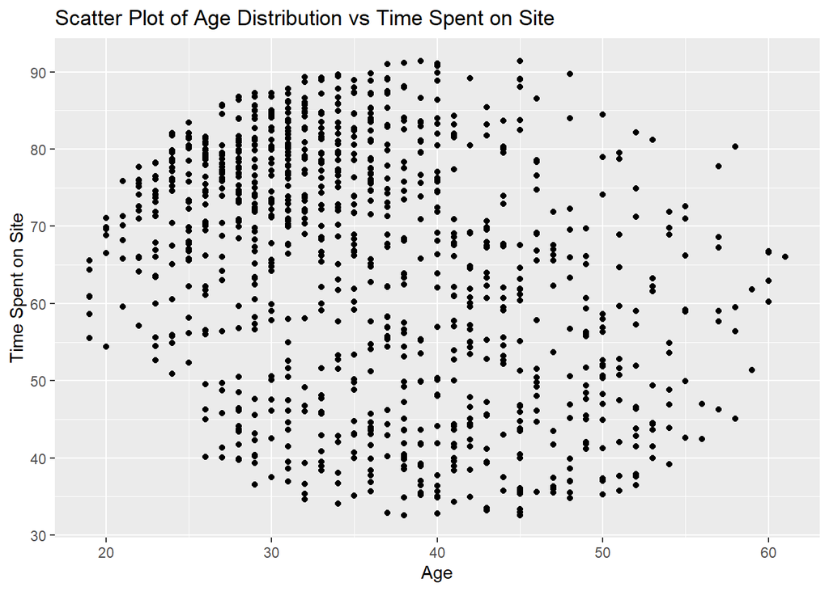

```r
ggplot(ad, aes(Age, Daily.Time.Spent.on.Site))+
  geom_point()+
  labs(title = "Scatter Plot of Age Distribution vs Time Spent on Site",
       x = "Age",
       y = "Time Spent on Site")
```

Scatter plot for Income Distribution and Daily time spent on site.

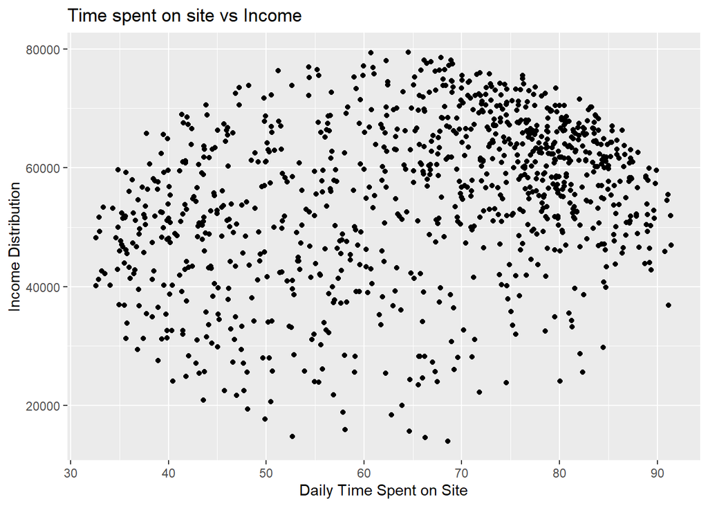

```r
ggplot(ad, aes(Daily.Time.Spent.on.Site, Area.Income))+
  geom_point()+
  labs(title = "Time spent on site vs Income",
       x = "Daily Time Spent on Site",
       y = "Income Distribution")
```

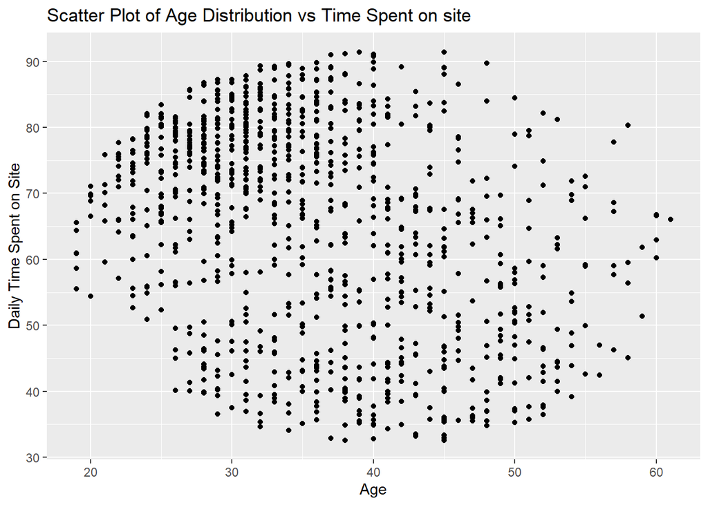

```r
ggplot(ad, aes(Age, Daily.Time.Spent.on.Site))+
  geom_point()+
  labs(title = "Scatter Plot of Age Distribution vs Time Spent on site",
       x = "Age",
       y = "Daily Time Spent on Site")
```

Scatter plot for Income and Daily Internet Usage

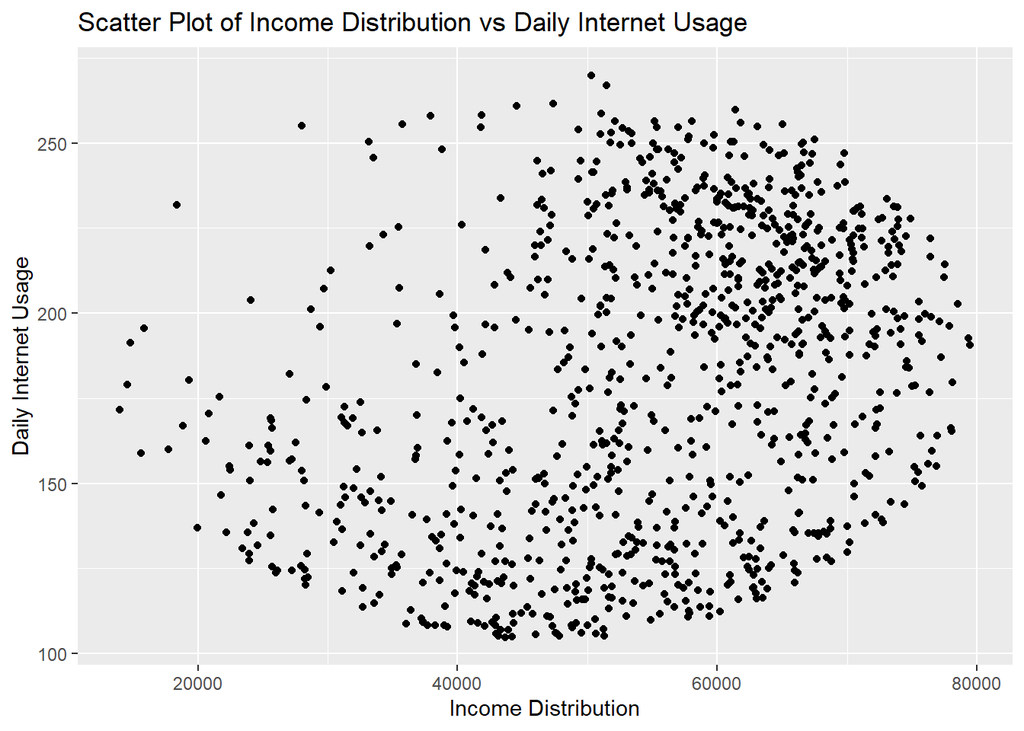

```r
ggplot(ad, aes(Area.Income, Daily.Internet.Usage))+
  geom_point()+
  labs(title = "Scatter Plot of Income Distribution vs Daily Internet Usage",
       x = "Income Distribution",
       y = "Daily Internet Usage")
```

## Modelling

### Multiple Linear Regression

Since we’d already created the scatter plots and established the relationship between the variables, we will dive straight into modelling.

Defining the variables we’ll use in this model.

```r
input <- ad[,c("Clicked.on.Ad","Daily.Time.Spent.on.Site", "Age","Area.Income","Daily.Internet.Usage")]
```

```r
head(input)
```

```
##   Clicked.on.Ad Daily.Time.Spent.on.Site Age Area.Income Daily.Internet.Usage
## 1             0                    68.95  35    61833.90               256.09
## 2             0                    80.23  31    68441.85               193.77
## 3             0                    69.47  26    59785.94               236.50
## 4             0                    74.15  29    54806.18               245.89
## 5             0                    68.37  35    73889.99               225.58
## 6             0                    59.99  23    59761.56               226.74
```

Applying the lm() function

```r
multiple_lm <- lm(Clicked.on.Ad ~ Daily.Time.Spent.on.Site + Age + Area.Income + Daily.Internet.Usage, data = input)
multiple_lm
```

```
##
## Call:
## lm(formula = Clicked.on.Ad ~ Daily.Time.Spent.on.Site + Age +
##     Area.Income + Daily.Internet.Usage, data = input)
##
## Coefficients:
##              (Intercept)  Daily.Time.Spent.on.Site                       Age
##                2.293e+00                -1.275e-02                 9.017e-03
##              Area.Income      Daily.Internet.Usage
##               -6.170e-06                -5.276e-03
```

Let’s assess our model.

```r
summary(multiple_lm)
```

```
##
## Call:
## lm(formula = Clicked.on.Ad ~ Daily.Time.Spent.on.Site + Age +
##     Area.Income + Daily.Internet.Usage, data = input)
##
## Residuals:
##      Min       1Q   Median       3Q      Max
## -0.63848 -0.11736 -0.03329  0.04825  1.02093
##
## Coefficients:
##                            Estimate Std. Error t value Pr(>|t|)
## (Intercept)               2.293e+00  5.722e-02   40.07   <2e-16 ***
## Daily.Time.Spent.on.Site -1.275e-02  5.064e-04  -25.18   <2e-16 ***
## Age                       9.017e-03  8.297e-04   10.87   <2e-16 ***
## Area.Income              -6.169e-06  5.361e-07  -11.51   <2e-16 ***
## Daily.Internet.Usage     -5.276e-03  1.869e-04  -28.22   <2e-16 ***
## ---
## Signif. codes:  0 '***' 0.001 '**' 0.01 '*' 0.05 '.' 0.1 ' ' 1
##
## Residual standard error: 0.2108 on 995 degrees of freedom
## Multiple R-squared:  0.8232, Adjusted R-squared:  0.8225
## F-statistic:  1158 on 4 and 995 DF,  p-value: < 2.2e-16
```

```r
library(broom)

tidy(multiple_lm)
```

```
## # A tibble: 5 x 5
##   term                        estimate   std.error statistic   p.value
##   <chr>                          <dbl>       <dbl>     <dbl>     <dbl>
## 1 (Intercept)               2.29       0.0572           40.1 8.00e-210
## 2 Daily.Time.Spent.on.Site -0.0127     0.000506        -25.2 1.28e-108
## 3 Age                       0.00902    0.000830         10.9 4.48e- 26
## 4 Area.Income              -0.00000617 0.000000536     -11.5 7.39e- 29
## 5 Daily.Internet.Usage     -0.00528    0.000187        -28.2 3.45e-129
```

Checking our model’s confidence intervals.

```r
library(MASS)
confint(multiple_lm)
```

```
##                                  2.5 %        97.5 %
## (Intercept)               2.180655e+00  2.405221e+00
## Daily.Time.Spent.on.Site -1.374279e-02 -1.175543e-02
## Age                       7.388911e-03  1.064533e-02
## Area.Income              -7.221617e-06 -5.117457e-06
## Daily.Internet.Usage     -5.642504e-03 -4.908785e-03
```

Generating the ANOVA table

```r
anova(multiple_lm)
```

```
## Analysis of Variance Table
##
## Response: Clicked.on.Ad
##                           Df  Sum Sq Mean Sq F value    Pr(>F)
## Daily.Time.Spent.on.Site   1 139.920 139.920 3150.14 < 2.2e-16 ***
## Age                        1  16.793  16.793  378.08 < 2.2e-16 ***
## Area.Income                1  13.721  13.721  308.91 < 2.2e-16 ***
## Daily.Internet.Usage       1  35.372  35.372  796.35 < 2.2e-16 ***
## Residuals                995  44.195   0.044
## ---
## Signif. codes:  0 '***' 0.001 '**' 0.01 '*' 0.05 '.' 0.1 ' ' 1
```

Predicting the response variable

```r
pred <- predict(multiple_lm, input)
pred
```

[output not shown]

[output cut: 345 more lines]

```
##  0.9192475132  0.1020508901  0.1370215778  0.1633168614  0.0910256676
##           966           967           968           969           970
##  0.9783088179  1.0321595658  0.2360529960  1.1818904032  0.4630651697
##           971           972           973           974           975
##  0.9273214585  1.2407846885  1.1162470605  0.0499153412  1.1815762054
##           976           977           978           979           980
##  1.1866398516  1.0690888392  0.9374717662  0.3304009239 -0.0186151321
##           981           982           983           984           985
##  0.9024876509  0.1105022062  0.7543495764 -0.0485895204  0.0143476999
##           986           987           988           989           990
##  0.7055279684 -0.0266310544  1.0523621113  0.1859560200 -0.0253665479
##           991           992           993           994           995
##  1.1510376126  1.1715876447  0.7112068269  0.1085834501  0.6860781611
##           996           997           998           999          1000
##  0.0923456762  0.9173425996  1.1978601695  0.5058612621  0.8283149091
```

Let’s cross validate our multiple linear regression model.

```r
library(caret)
multiple_lm2 <- train(Clicked.on.Ad ~ Daily.Time.Spent.on.Site + Age + Area.Income + Daily.Internet.Usage, data = input,
               method = "lm",
               trControl = trainControl(method = "cv",
                                        number = 10,
                                        verboseIter = FALSE))
summary(multiple_lm2)
```

```
##
## Call:
## lm(formula = .outcome ~ ., data = dat)
##
## Residuals:
##      Min       1Q   Median       3Q      Max
## -0.63848 -0.11736 -0.03329  0.04825  1.02093
##
## Coefficients:
##                            Estimate Std. Error t value Pr(>|t|)
## (Intercept)               2.293e+00  5.722e-02   40.07   <2e-16 ***
## Daily.Time.Spent.on.Site -1.275e-02  5.064e-04  -25.18   <2e-16 ***
## Age                       9.017e-03  8.297e-04   10.87   <2e-16 ***
## Area.Income              -6.169e-06  5.361e-07  -11.51   <2e-16 ***
## Daily.Internet.Usage     -5.276e-03  1.869e-04  -28.22   <2e-16 ***
## ---
## Signif. codes:  0 '***' 0.001 '**' 0.01 '*' 0.05 '.' 0.1 ' ' 1
##
## Residual standard error: 0.2108 on 995 degrees of freedom
## Multiple R-squared:  0.8232, Adjusted R-squared:  0.8225
## F-statistic:  1158 on 4 and 995 DF,  p-value: < 2.2e-16
```

```r
multiple_lm2
```

```
## Linear Regression
##
## 1000 samples
##    4 predictor
##
## No pre-processing
## Resampling: Cross-Validated (10 fold)
## Summary of sample sizes: 900, 900, 900, 900, 900, 900, ...
## Resampling results:
##
##   RMSE       Rsquared   MAE
##   0.2087357  0.8233885  0.1444773
##
## Tuning parameter 'intercept' was held constant at a value of TRUE
```

Our model has an RMSE value of 0.2088.

Let’s use this train object as input to the predict method

```r
pred2 <- predict(multiple_lm2, input)
pred2
```

[output not shown]

[output cut: 345 more lines]

```
##  0.9192475132  0.1020508901  0.1370215778  0.1633168614  0.0910256676
##           966           967           968           969           970
##  0.9783088179  1.0321595658  0.2360529960  1.1818904032  0.4630651697
##           971           972           973           974           975
##  0.9273214585  1.2407846885  1.1162470605  0.0499153412  1.1815762054
##           976           977           978           979           980
##  1.1866398516  1.0690888392  0.9374717662  0.3304009239 -0.0186151321
##           981           982           983           984           985
##  0.9024876509  0.1105022062  0.7543495764 -0.0485895204  0.0143476999
##           986           987           988           989           990
##  0.7055279684 -0.0266310544  1.0523621113  0.1859560200 -0.0253665479
##           991           992           993           994           995
##  1.1510376126  1.1715876447  0.7112068269  0.1085834501  0.6860781611
##           996           997           998           999          1000
##  0.0923456762  0.9173425996  1.1978601695  0.5058612621  0.8283149091
```

```r
error <- pred2 - ad$Clicked.on.Ad
error
```

[output not shown]

[output cut: 345 more lines]

```
## -8.075249e-02  1.020509e-01  1.370216e-01  1.633169e-01  9.102567e-02
##           966           967           968           969           970
## -2.169118e-02  3.215957e-02  2.360530e-01  1.818904e-01 -5.369348e-01
##           971           972           973           974           975
## -7.267854e-02  2.407847e-01  1.162471e-01  4.991534e-02  1.815762e-01
##           976           977           978           979           980
##  1.866399e-01  6.908884e-02 -6.252823e-02  3.304009e-01 -1.861513e-02
##           981           982           983           984           985
## -9.751235e-02  1.105022e-01 -2.456504e-01 -4.858952e-02  1.434770e-02
##           986           987           988           989           990
## -2.944720e-01 -2.663105e-02  5.236211e-02  1.859560e-01 -2.536655e-02
##           991           992           993           994           995
##  1.510376e-01  1.715876e-01 -2.887932e-01  1.085835e-01 -3.139218e-01
##           996           997           998           999          1000
## -9.076543e-01 -8.265740e-02  1.978602e-01  5.058613e-01 -1.716851e-01
```

```r
rmse_xval <- sqrt(mean(error^2))

rmse_xval
```

```
## [1] 0.2102259
```

### K-Nearest Neighbours

The features in our dataset have very different ranges when compared to other features. If the distance formula was applied to unmodified features, there is a potential for the features with larger ranges to dominate or mask the features with smaller ranges. Because of this, it is important to prepare the data with feature scaling.

```r
#Randomizing our data for better results
random <- runif(1000, 1:4)
ad_random <- ad[order(random),]

# Selecting the first 6 rows from ad_random
head(ad_random)
```

```
##    Daily.Time.Spent.on.Site Age Area.Income Daily.Internet.Usage
## 1                     68.95  35    61833.90               256.09
## 5                     68.37  35    73889.99               225.58
## 9                     74.53  30    68862.00               221.51
## 13                    69.57  48    51636.92               113.12
## 17                    55.39  37    23936.86               129.41
## 21                    77.22  30    64802.33               224.44
##                            Ad.Topic.Line            City Male
## 1     Cloned 5thgeneration orchestration     Wrightburgh    0
## 5          Robust logistical utilization    South Manuel    0
## 9         Configurable coherent function      West Colin    1
## 13 Centralized content-based focus group  West Katiefurt    1
## 17    Customizable multi-tasking website  West Dylanberg    0
## 21 Object-based reciprocal knowledgebase Port Jacqueline    1
##                  Country           Timestamp Clicked.on.Ad
## 1                Tunisia 2016-03-27 00:53:11             0
## 5                Iceland 2016-06-03 03:36:18             0
## 9                Grenada 2016-04-18 09:33:42             0
## 13                 Egypt 2016-06-03 01:14:41             1
## 17 Palestinian Territory 2016-01-30 19:20:41             1
## 21              Cameroon 2016-01-05 07:52:48             0
```

Let’s normalize our dataset. We will use the Min-Max Normalization

```r
normal <- function(x) (
  return( ((x - min(x)) /(max(x)-min(x))) )
)
normal(1:4)
```

```
## [1] 0.0000000 0.3333333 0.6666667 1.0000000
```

```r
ad_new <- as.data.frame(lapply(ad_random[1:4], normal))
summary(ad_new)
```

```
##  Daily.Time.Spent.on.Site      Age          Area.Income
##  Min.   :0.0000           Min.   :0.0000   Min.   :0.0000
##  1st Qu.:0.3189           1st Qu.:0.2381   1st Qu.:0.5044
##  Median :0.6054           Median :0.3810   Median :0.6568
##  Mean   :0.5507           Mean   :0.4050   Mean   :0.6261
##  3rd Qu.:0.7810           3rd Qu.:0.5476   3rd Qu.:0.7860
##  Max.   :1.0000           Max.   :1.0000   Max.   :1.0000
##  Daily.Internet.Usage
##  Min.   :0.0000
##  1st Qu.:0.2061
##  Median :0.4743
##  Mean   :0.4554
##  3rd Qu.:0.6902
##  Max.   :1.0000
```

Let’s create test and train datasets

```r
train <- ad_new[1:800,]
test <- ad_new[801:1000,]
train_sp <- ad_random[1:800,10]
test_sp <- ad_random[801:1000,10]
```

Let’s call the class package which contains the KNN algorithm. The table(test_sp, model) is our confusion matrix.

```r
library(class)
require(class)

model <- knn(train= train,test=test, ,cl= train_sp, k=10)
table(factor(model))
```

```
##
##   0   1
## 102  98
```

```r
table(test_sp,model)
```

```
##        model
## test_sp  0  1
##       0 92  1
##       1 10 97
```

### Decision Trees

Decision trees make a complex decision simpler by breaking it down into smaller, simpler decisions using divide-and-conquer strategy. They basically identify a set of if-else conditions that split data according to the value if the features. Let’s implement the decision tree model into our dataset and see how it performs. Let’s call the libraries we need.

```r
library(rpart.plot)
library(mlbench)
library(rpart)
```

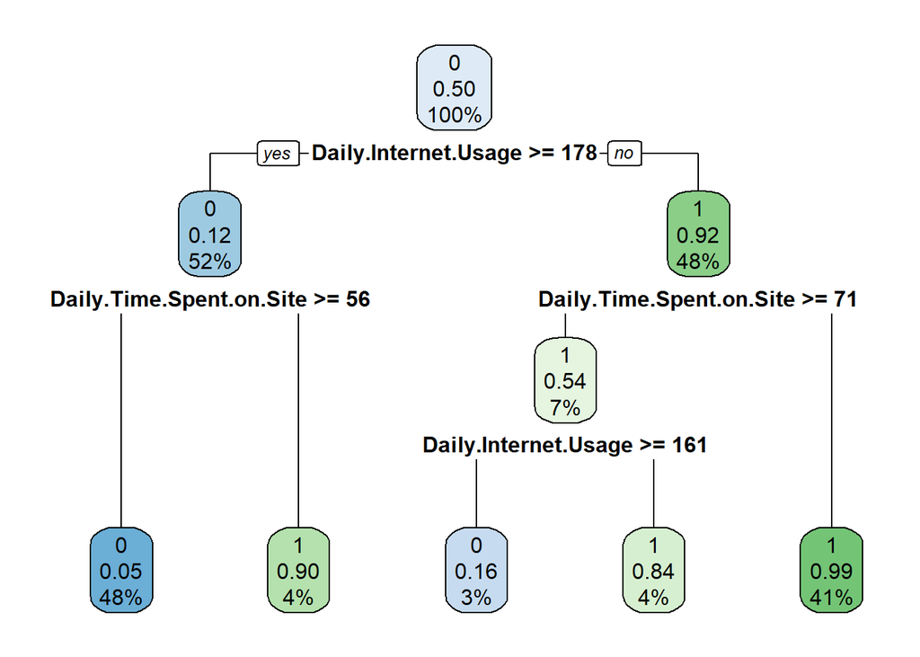

```r
dt <- rpart(Clicked.on.Ad ~ Daily.Time.Spent.on.Site + Age + Area.Income + Daily.Internet.Usage, data = input, method  ="class")
rpart.plot(dt)
```

Looking for feature importances.

```r
data.frame(dt$variable.importance)
```

```
##                          dt.variable.importance
## Daily.Internet.Usage                   339.7809
## Daily.Time.Spent.on.Site               279.0247
## Age                                    126.2649
## Area.Income                            119.2524
```

```r
pr <- predict(dt, input, type = "class")
table(pr, ad$Clicked.on.Ad)
```

```
##
## pr    0   1
##   0 485  28
##   1  15 472
```

This decision tree algorithm predicts 957 correct observations out of 1000. This model achieves an accuracy of 95.7 %.

Let’s train our model.

```r
library(caret)
set.seed(12)

model <- train(Clicked.on.Ad ~ Daily.Time.Spent.on.Site + Age + Area.Income + Daily.Internet.Usage ,data = input,method = "ranger")
model
```

```
## Random Forest
##
## 1000 samples
##    4 predictor
##
## No pre-processing
## Resampling: Bootstrapped (25 reps)
## Summary of sample sizes: 1000, 1000, 1000, 1000, 1000, 1000, ...
## Resampling results across tuning parameters:
##
##   mtry  splitrule   RMSE       Rsquared   MAE
##   2     variance    0.1713734  0.8825549  0.06331311
##   2     extratrees  0.1647794  0.8923250  0.06987902
##   3     variance    0.1776455  0.8737515  0.05998737
##   3     extratrees  0.1661163  0.8898515  0.06574389
##   4     variance    0.1857072  0.8623095  0.05935058
##   4     extratrees  0.1674823  0.8878285  0.06395853
##
## Tuning parameter 'min.node.size' was held constant at a value of 5
## RMSE was used to select the optimal model using the smallest value.
## The final values used for the model were mtry = 2, splitrule = extratrees
##  and min.node.size = 5.
```

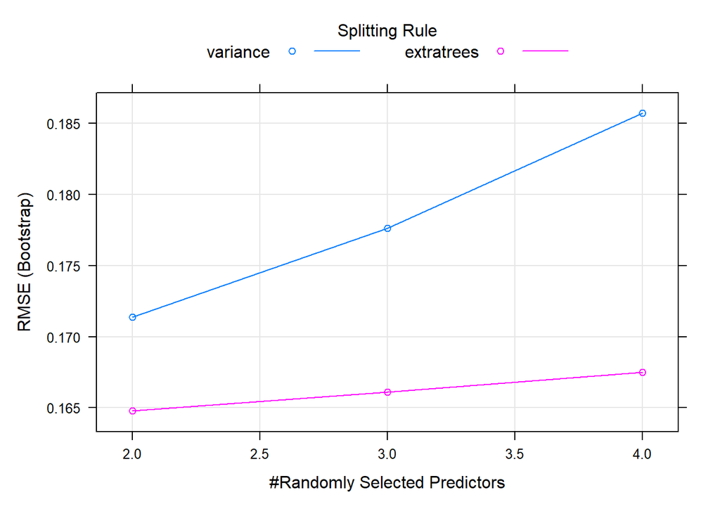

```r
plot(model)
```

### Support Vector Machines

```r
library(caret)
intrain <- createDataPartition(y = ad$Clicked.on.Ad, p= 0.7, list = FALSE)
training <- ad[intrain,]
testing <- ad[-intrain,]
```

Checking the dimension of the training and testing dataframe.

```r
dim(training);
```

```
## [1] 700  10
```

```r
dim(testing);
```

```
## [1] 300  10
```

Let’s factorize our target variable for accurate results.

```r
training[["Clicked.on.Ad"]] = factor(training[["Clicked.on.Ad"]])
```

Controlling the computational overheads using the trainControl() method.

```r
trctrl <- trainControl(method = "repeatedcv", number = 10, repeats = 3)
```

```r
svm_Linear <- train(Clicked.on.Ad ~ Daily.Time.Spent.on.Site + Age + Area.Income +Daily.Internet.Usage , data = training, method = "svmLinear",
trControl=trctrl,
preProcess = c("center", "scale"),
tuneLength = 10)
```

Checking the result of our training model.

```r
svm_Linear
```

```
## Support Vector Machines with Linear Kernel
##
## 700 samples
##   4 predictor
##   2 classes: '0', '1'
##
## Pre-processing: centered (4), scaled (4)
## Resampling: Cross-Validated (10 fold, repeated 3 times)
## Summary of sample sizes: 630, 630, 630, 630, 630, 630, ...
## Resampling results:
##
##   Accuracy   Kappa
##   0.9695238  0.9390476
##
## Tuning parameter 'C' was held constant at a value of 1
```

Predicting our model results using the predict() method.

```r
test_pred <- predict(svm_Linear, newdata = testing)
test_pred
```

```
##   [1] 0 0 0 1 1 1 1 1 1 0 0 1 1 0 0 0 0 0 1 0 1 0 0 1 1 1 1 1 1 0 1 1 1 0 0 1 0
##  [38] 1 1 0 0 0 0 1 0 1 1 1 0 0 0 1 1 0 0 1 0 1 0 1 1 0 1 0 1 0 0 1 1 0 0 1 1 1
##  [75] 1 1 0 0 1 1 1 0 0 1 1 0 0 0 0 0 0 0 1 1 0 0 0 0 0 1 0 0 1 0 0 0 1 0 1 0 1
## [112] 0 0 1 0 0 0 1 0 1 0 0 0 0 0 0 0 1 0 0 1 0 1 0 0 0 1 0 0 1 1 0 0 0 0 1 0 0
## [149] 0 1 1 0 0 1 0 1 0 1 1 1 0 0 0 0 0 0 0 1 1 1 1 0 1 1 0 0 0 1 1 1 0 1 0 0 1
## [186] 0 1 0 0 0 0 0 1 1 1 0 1 0 1 1 0 1 0 1 0 0 0 0 1 0 0 0 1 1 0 1 0 0 0 0 1 1
## [223] 0 0 0 1 1 0 1 1 1 1 1 0 1 1 1 0 0 0 1 1 0 0 1 0 0 0 0 1 0 1 0 1 1 0 0 1 0
## [260] 1 1 1 1 1 1 1 1 1 0 0 0 1 0 1 0 1 0 0 1 1 1 1 1 1 1 0 1 0 1 1 0 0 1 1 1 1
## [297] 1 1 1 1
## Levels: 0 1
```

Checking the accuracy of our model using a confusion matrix.

```r
confusionMatrix(table(test_pred, testing$Clicked.on.Ad))
```

```
## Confusion Matrix and Statistics
##
##
## test_pred   0   1
##         0 147   9
##         1   3 141
##
##                Accuracy : 0.96
##                  95% CI : (0.9312, 0.9792)
##     No Information Rate : 0.5
##     P-Value [Acc > NIR] : <2e-16
##
##                   Kappa : 0.92
##
##  Mcnemar's Test P-Value : 0.1489
##
##             Sensitivity : 0.9800
##             Specificity : 0.9400
##          Pos Pred Value : 0.9423
##          Neg Pred Value : 0.9792
##              Prevalence : 0.5000
##          Detection Rate : 0.4900
##    Detection Prevalence : 0.5200
##       Balanced Accuracy : 0.9600
##
##        'Positive' Class : 0
##
```

## Conclusion and Recommendations

- Since the data shows that most of the respondents fall in the age bracket 25-41, she should tailor make the course to attract or suit more people in that age bracket. Also prudent to note that the youngest respondent is 19 and the oldest 61.
- Our client should target people with an income of 50,000 to 70,000 since those are the ones who seem interested and are in a position to afford the course.
- Most people spent about 70-85 minutes on the site so she should ensure that her course takes about the same time or even shorter per day so as to keep people interested.
- The client should implement the SVM model with this dataset because it has the highest accuracy.
- When she’s coming up with the blog strategy, our client should prioritize the following features because they are the most important to figure out which clients will click on her adverts: Daily Internet Usage Daily Time Spent on Site Age Income distribution of the area.